# Camera Dataset for CSE4202 Data Mining & Visualization

Farnaz Baksh

5/21/2020

##Import Libraries

##Load Dataset & preview

```r
data<-read.csv("/Users/Dell/Desktop/DataMining-Visualization/camera_dataset.csv")
head(data)
```

```
##   Brand                Model Release.date Max.resolution Low.resolution
## 1     1  Canon PowerShot 350         1997            640              0
## 2     1  Canon PowerShot 600         1996            832            640
## 3     1  Canon PowerShot A10         2001           1280           1024
## 4     1 Canon PowerShot A100         2002           1280           1024
## 5     1  Canon PowerShot A20         2001           1600           1024
## 6     1 Canon PowerShot A200         2002           1600           1024
##   Effective.pixels Zoom.wide..W. Zoom.tele..T. Normal.focus.range
## 1                0            42            42                 70
## 2                0            50            50                 40
## 3                1            35           105                 76
## 4                1            39            39                 20
## 5                1            35           105                 76
## 6                1            39            39                 20
##   Macro.focus.range Storage.included Weight..inc..batteries. Dimensions Price
## 1                 3                2                     320         93   149
## 2                10                1                     460        160   139
## 3                16                8                     375        110   139
## 4                 5                8                     225        110   139
## 5                16                8                     375        110   139
## 6                 5                8                     225        110   139
```

#### Dimension of the Dataset

```r
dimension<-dim(data)
cat("The dimension of the dataset is:", dimension)
```

```
## The dimension of the dataset is: 258 14
```

#### Summary of the Dataset | General Statistical Operation of the Dataset

```r
summary(data)
```

```
##      Brand          Model            Release.date  Max.resolution
##  Min.   :1.000   Length:258         Min.   :1996   Min.   : 512
##  1st Qu.:1.000   Class :character   1st Qu.:2002   1st Qu.:2048
##  Median :2.000   Mode  :character   Median :2004   Median :2592
##  Mean   :1.907                      Mean   :2004   Mean   :2547
##  3rd Qu.:3.000                      3rd Qu.:2006   3rd Qu.:3072
##  Max.   :3.000                      Max.   :2007   Max.   :4256
##  Low.resolution Effective.pixels Zoom.wide..W.  Zoom.tele..T.
##  Min.   :   0   Min.   : 0.000   Min.   : 0.0   Min.   :  0.0
##  1st Qu.:1600   1st Qu.: 3.000   1st Qu.:35.0   1st Qu.:105.0
##  Median :2048   Median : 5.000   Median :36.0   Median :111.5
##  Mean   :1894   Mean   : 4.597   Mean   :35.1   Mean   :131.9
##  3rd Qu.:2304   3rd Qu.: 6.750   3rd Qu.:38.0   3rd Qu.:138.2
##  Max.   :3264   Max.   :12.000   Max.   :52.0   Max.   :486.0
##  Normal.focus.range Macro.focus.range Storage.included Weight..inc..batteries.
##  Min.   : 0.00      Min.   : 0.000    Min.   : 0.00    Min.   :120.0
##  1st Qu.:30.00      1st Qu.: 4.000    1st Qu.:12.00    1st Qu.:185.0
##  Median :50.00      Median : 5.000    Median :16.00    Median :225.0
##  Mean   :42.84      Mean   : 6.671    Mean   :17.65    Mean   :284.2
##  3rd Qu.:60.00      3rd Qu.:10.000    3rd Qu.:19.00    3rd Qu.:320.0
##  Max.   :90.00      Max.   :20.000    Max.   :64.00    Max.   :930.0
##    Dimensions        Price
##  Min.   : 60.0   Min.   :  99.0
##  1st Qu.: 90.0   1st Qu.: 159.0
##  Median : 98.0   Median : 199.0
##  Mean   :100.6   Mean   : 251.8
##  3rd Qu.:110.0   3rd Qu.: 229.0
##  Max.   :160.0   Max.   :1699.0
```

##Question 1: Which year had the most camera releases?

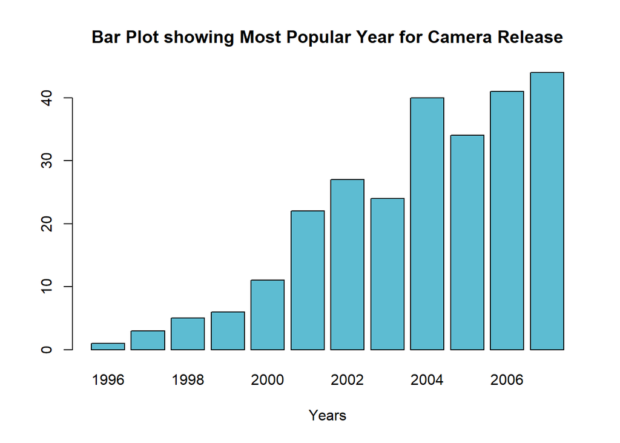

```r
Year <- table(data$Release.date)
barplot(Year,
        main ="Bar Plot showing Most Popular Year for Camera Release",
        xlab="Years",
        col = "#5dbcd2")
```

##Question 2: Has there been an increase in Max Resolution over the years?

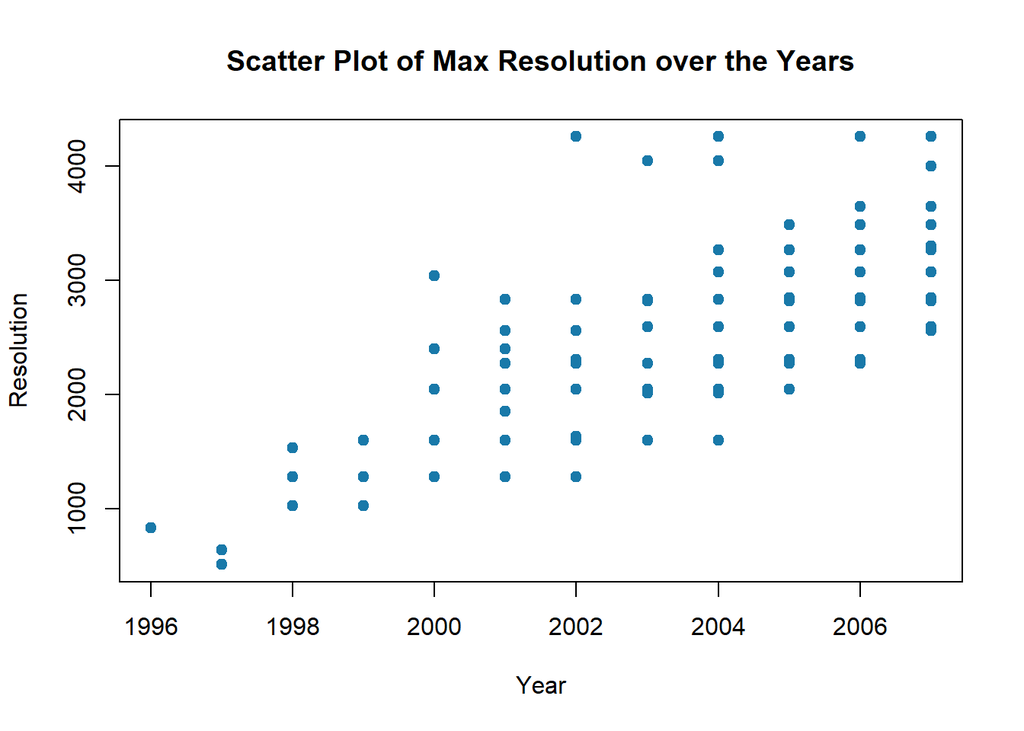

```r
plot(data$Release.date, data$Max.resolution,
     main ="Scatter Plot of Max Resolution over the Years",
     pch = 20,
     cex=1.5,
     col="#1979a9",
     ylab = "Resolution",
     xlab = "Year")
```

###Output for Question 2: Has there been an increase in Max Resolution over the years? The visualization plot shows a steadily increase in the camera’s max resolution over the period of 1996-2007. From the year 2000, resolution has entered in the 3000 dimensions in pixels. Then from 2002, the dimensions increased by another 1000 pixels.

##Question 3: Has there been a decrease in Low Resolution over the years?

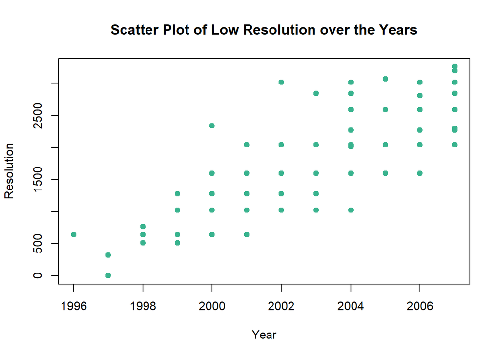

```r
plot(data$Release.date, data$Low.resolution,
     main ="Scatter Plot of Low Resolution over the Years",
     pch = 20,
     cex=1.5,
     col="#39b38e",
     ylab = "Resolution",
     xlab = "Year")
```

##Question 4: Is there any relationship between Dimension and Year?

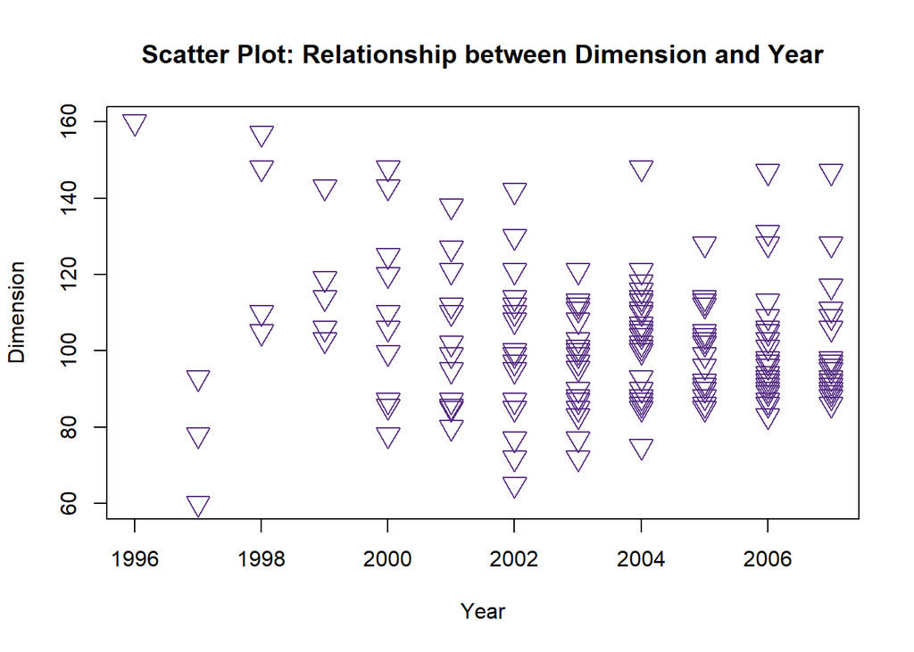

```r
plot(data$Release.date, data$Dimensions,
     main ="Scatter Plot: Relationship between Dimension and Year",
     pch = 25,
     cex=1.8,
     col="#552b82",
     ylab = "Dimension",
     xlab = "Year")
```

###Output for Question 4: Is there any relationship between Dimension and Year? It is evident from our scatter plot that most cameras has a dimension between 80 to 120 from 2000 onwards. Based on our dataset, we can conclude that camera models of Canon Powershot, Fujifilm FinePix and Nikon Coolpix falls most popularly in these dimensions.

##Question 5: What is the is the most popular storage size for cameras?

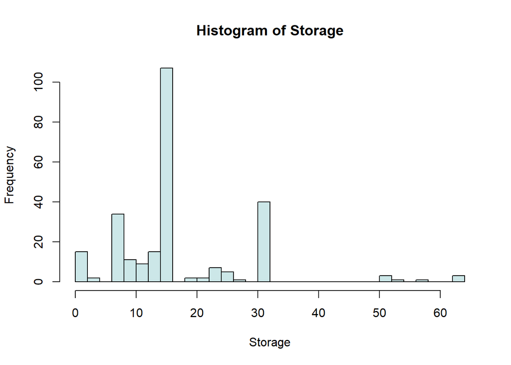

```r
hist(data$Storage.included,
     main = "Histogram of Storage",
     xlab="Storage",
     breaks = 30,
     col = "#cce7e8")
```

###Output for Question 5: What is the most popular storage size for cameras? From the year 1996 to 2007, the most popular storage size from our cameras dataset is 16GB. The runner up storage included for our cameras are 32GB and 8GB.

##Question 6: What is the average price for a Canon Powershot camera?

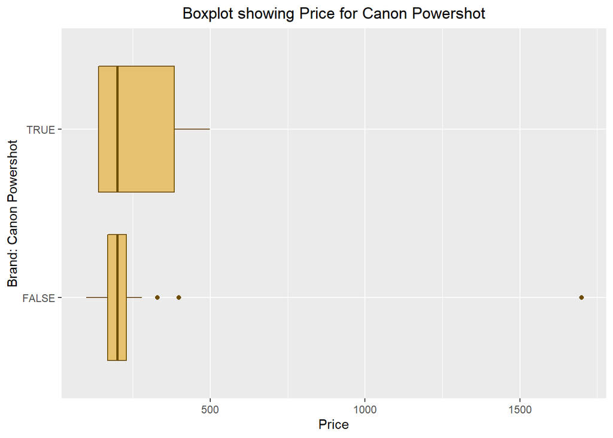

```r
ggplot(data, aes( x=Price, y=Brand == "1")) +
  geom_boxplot(color="#6e4d00", fill="#e6c26e") + ylab("Brand: Canon Powershot") + ggtitle("Boxplot showing Price for Canon Powershot")+ theme(plot.title = element_text(hjust = 0.5))
```

###Output for Question 6: What is the average price for a Canon PowerShot camera? Based on the box plot diagram, the average price for a Canon PowerShot camera falls below $500. The FALSE value shows the prices for the other brands (i.e. Fujifilm FinePix and Nikon Coolpix) which shows some outliers.

##Question 7: What is the weight distribution of the cameras over the period of time?

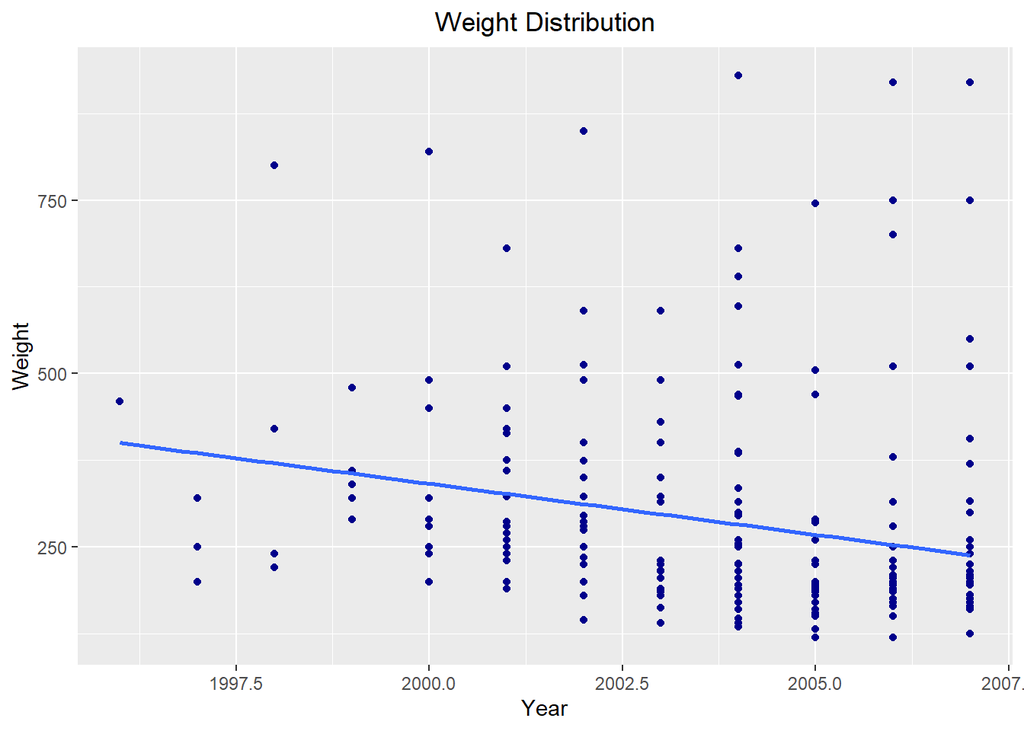

```r
Year <- table(data$Release.date, data$Weight..inc..batteries.)
#Year
ggplot(data, aes(x=Release.date, y=Weight..inc..batteries.)) +
  geom_point(color='darkblue')+
  geom_smooth(method=lm, se=FALSE) +ylab("Weight")+ xlab("Year") + ggtitle("Weight Distribution")+ theme(plot.title = element_text(hjust = 0.5))
```

###Output for Question 7: What is the weight distribution of the cameras over the period of time? The diagram shows that there has been a decline in camera weight from the years 1996 to 2007. The slope depicts a fall in the data visualization diagram.

##Question 8: Which brand has the widest variety of affordable camera models? [Based on our Dataset]

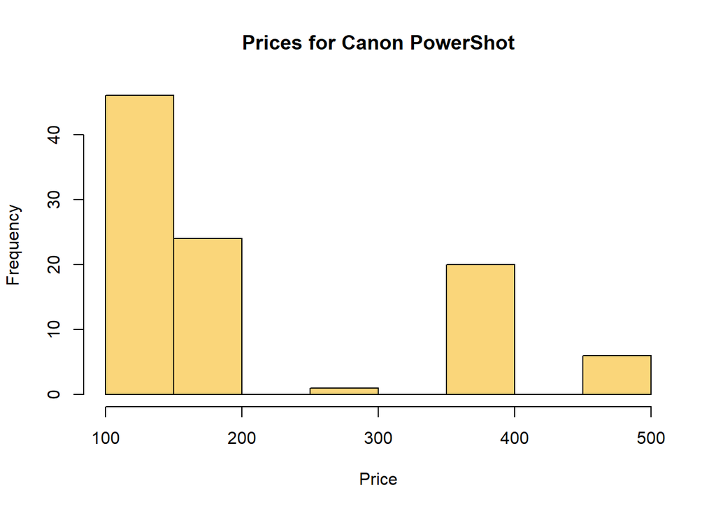

```r
hist(data$Price [data$Brand =="1"],
     main ="Prices for Canon PowerShot",
     col = "#fad67a",
     xlab = "Price")
```

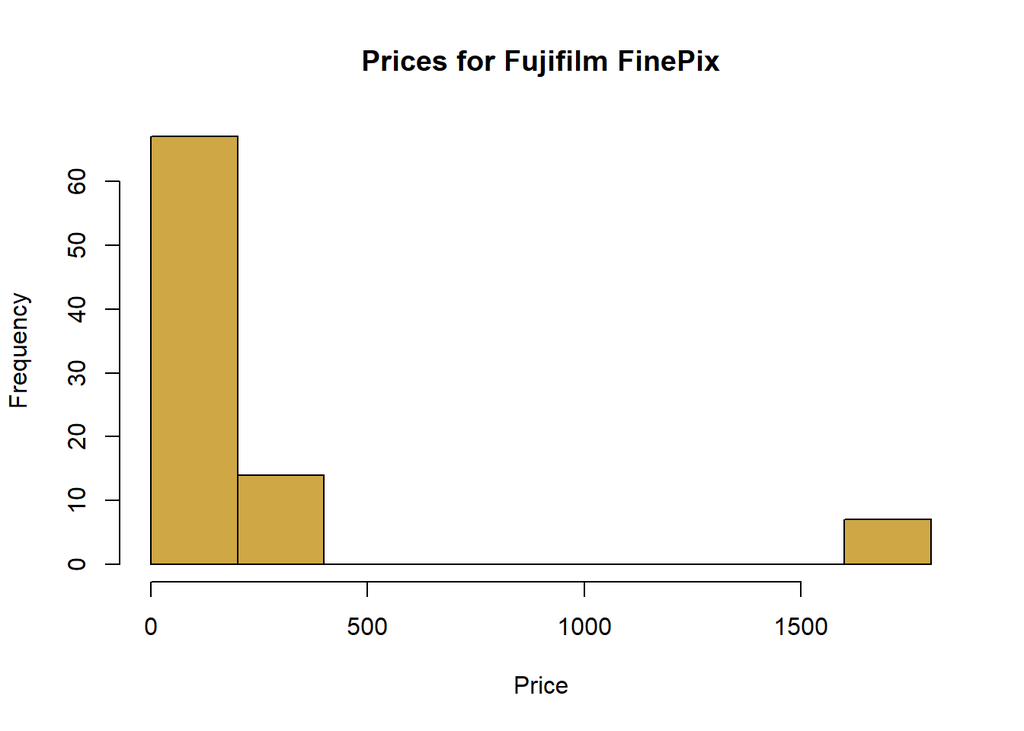

```r
hist(data$Price [data$Brand =="2"],
     main = "Prices for Fujifilm FinePix",
     col = "#cfa744",
     xlab = "Price")
```

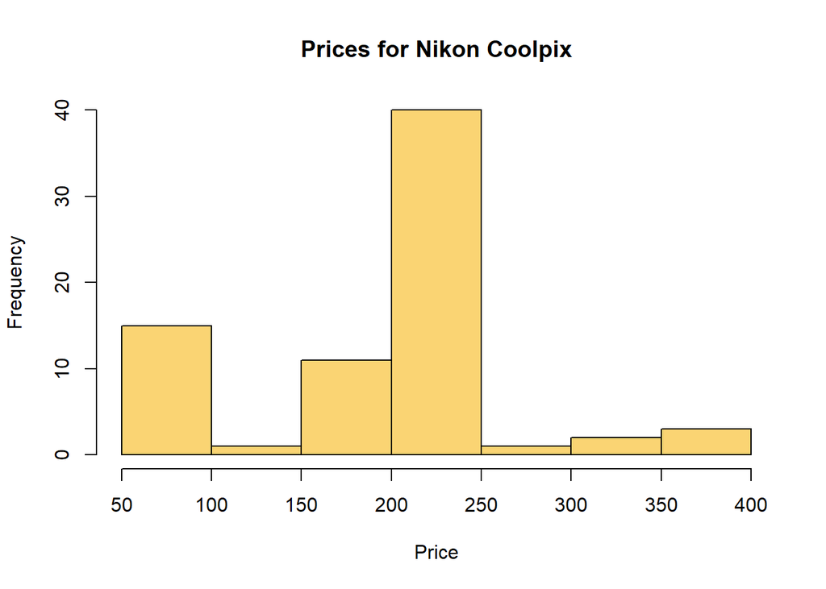

```r
hist(data$Price [data$Brand =="3"],
     main = "Prices for Nikon Coolpix",
     col = "#fad473",
     xlab = "Price")
```

###Output for Question 8: Which camera brand has the most affordable variety of models? (based on our dataset) Based on the visualization, it can be seen that most Canon PowerShot models falls in the price range of 100-150. Whereas for the Nikon Coolpix models, the prices fall between 200-250. However for the Fujifilm FinePix, thef=re seems to be many outliers, thus it is hard to determine a narrow range for the prices. It can be shown that most camera prices for Fujifilm FinePix falls below 250. In conclusion, the widest variety of the cheapest camera cost is the Canon PowerShot.

##Question 9: What are the prices of Cameras with Max Resolution more than 4000 pixels?

```r
#filter the dataset  to extract observations where max resolution is greater than 4000
filtered_maxRes<-data%>%
  filter(Max.resolution>4000)
filtered_maxRes[, c(1:2,4, 14)]
```

```
##   Brand                      Model Max.resolution Price
## 1     2 Fujifilm FinePix E550 Zoom           4048   169
## 2     2      Fujifilm FinePix F610           4048   169
## 3     2 Fujifilm FinePix F810 Zoom           4048   169
## 4     2   Fujifilm FinePix S7000 Z           4048   229
## 5     2    Fujifilm FinePix IS Pro           4256  1699
## 6     2    Fujifilm FinePix S2 Pro           4256  1699
## 7     2    Fujifilm FinePix S3 Pro           4256  1699
## 8     2    Fujifilm FinePix S5 Pro           4256  1699
```

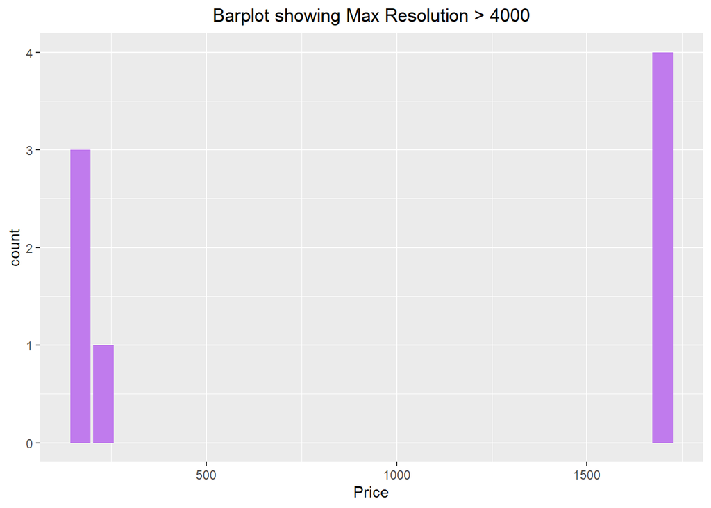

```r
ggplot(filtered_maxRes, aes(x = Price, fill = Max.resolution)) +
  geom_bar(position = "dodge", fill="#c07bed") + ggtitle("Barplot showing Max Resolution > 4000")+ theme(plot.title = element_text(hjust = 0.5))
```

###Output for Question 9: What are the prices of Cameras with Max Resolution more than 4000 pixels? The barplot shows that one could obtain four cameras in the price range of 1500-1800. Four other cameras are also available in the price range of 150-250. This is ideal for persons who wants large file formats so that they can manipulate their images in post edits.

##Question 10: Is there Correlation between Normal and Macro Focus Range?

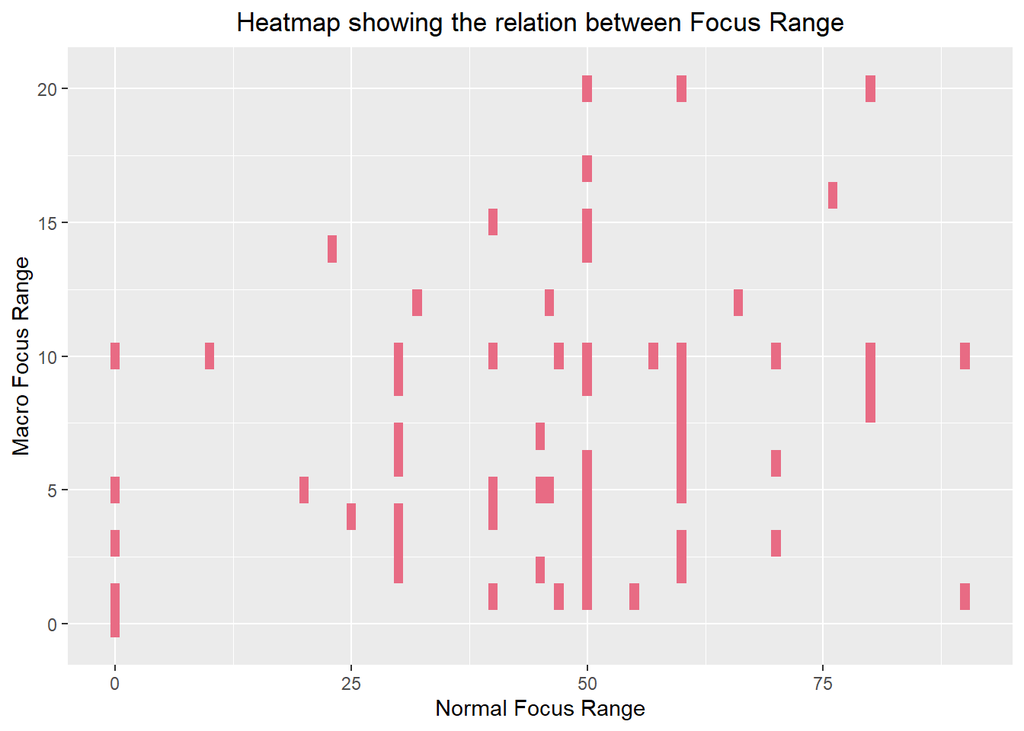

```r
#ggplot(data, mapping = aes(x = Normal.focus.range, y = Macro.focus.range, fill = "Abundance")) +
#  geom_tile() + xlab(label = "Normal Focus Range")

ggplot(data, mapping = aes(x = Normal.focus.range, y = Macro.focus.range)) +
  geom_tile(fill ="#e86b84") + xlab(label = "Normal Focus Range") + ylab(label = "Macro Focus Range") + ggtitle("Heatmap showing the relation between Focus Range") + theme(plot.title = element_text(hjust = 0.5))
```

###Output for Question 10: Is there a correlation between Normal and Macro Focus Range? Most cameras in our dataset has a normal focus distance that ranges between 25-75 and a Macro Focus range that is centered around 1-15. This range signifies how far away or how close someone can be with the camera to take clear and in-focus shots.

#### Summary of the Sub-Dataset of Variables we used in this Analysis

```r
sub_data<- data[, c(1:5, 9:14)]

dimension<-dim(sub_data)
cat("The dimension of the dataset is:", dimension, "\n", "\n")
```

```
## The dimension of the dataset is: 258 11
##
```

```r
summary(sub_data)
```

```
##      Brand          Model            Release.date  Max.resolution
##  Min.   :1.000   Length:258         Min.   :1996   Min.   : 512
##  1st Qu.:1.000   Class :character   1st Qu.:2002   1st Qu.:2048
##  Median :2.000   Mode  :character   Median :2004   Median :2592
##  Mean   :1.907                      Mean   :2004   Mean   :2547
##  3rd Qu.:3.000                      3rd Qu.:2006   3rd Qu.:3072
##  Max.   :3.000                      Max.   :2007   Max.   :4256
##  Low.resolution Normal.focus.range Macro.focus.range Storage.included
##  Min.   :   0   Min.   : 0.00      Min.   : 0.000    Min.   : 0.00
##  1st Qu.:1600   1st Qu.:30.00      1st Qu.: 4.000    1st Qu.:12.00
##  Median :2048   Median :50.00      Median : 5.000    Median :16.00
##  Mean   :1894   Mean   :42.84      Mean   : 6.671    Mean   :17.65
##  3rd Qu.:2304   3rd Qu.:60.00      3rd Qu.:10.000    3rd Qu.:19.00
##  Max.   :3264   Max.   :90.00      Max.   :20.000    Max.   :64.00
##  Weight..inc..batteries.   Dimensions        Price
##  Min.   :120.0           Min.   : 60.0   Min.   :  99.0
##  1st Qu.:185.0           1st Qu.: 90.0   1st Qu.: 159.0
##  Median :225.0           Median : 98.0   Median : 199.0
##  Mean   :284.2           Mean   :100.6   Mean   : 251.8
##  3rd Qu.:320.0           3rd Qu.:110.0   3rd Qu.: 229.0
##  Max.   :930.0           Max.   :160.0   Max.   :1699.0
```

##Prep for modeling

```r
sub_data$Release.date <- as.integer(data$Release.date)
sub_data$Max.resolution <- as.numeric(data$Max.resolution)
sub_data$Low.resolution <- as.numeric(data$Low.resolution)
sub_data$Dimensions <- as.numeric(data$Dimensions)
sub_data$Weight..inc..batteries. <- #as.numeric(data$Weight..inc..batteries.)
sub_data$Storage.included <- as.numeric(data$Storage.included)
sub_data$Price <- as.numeric(data$Price)

#attach(sub_data)

set.seed(134)
sampleSize<-floor(.75*nrow(sub_data))
trainIndexes<-sample(seq_len(nrow(sub_data)), sampleSize, replace = FALSE)
train <-sub_data[trainIndexes, ]
test <- sub_data[-trainIndexes, ]
```

##Modeling

```r
#linear_model1<-lm(Release.date ~ Weight..inc..batteries., data = sub_data)
linear_model1<-lm(Weight..inc..batteries. ~ Release.date, data = sub_data)
linear_model1
```

```
##
## Call:
## lm(formula = Weight..inc..batteries. ~ Release.date, data = sub_data)
##
## Coefficients:
##  (Intercept)  Release.date
##    -2283.605         1.148
```

```r
summary(linear_model1)
```

```
##
## Call:
## lm(formula = Weight..inc..batteries. ~ Release.date, data = sub_data)
##
## Residuals:
##     Min      1Q  Median      3Q     Max
## -21.222  -5.609  -1.776   2.817  50.817
##
## Coefficients:
##                Estimate Std. Error t value Pr(>|t|)
## (Intercept)  -2283.6054   529.4447  -4.313  2.3e-05 ***
## Release.date     1.1484     0.2642   4.347  2.0e-05 ***
## ---
## Signif. codes:  0 '***' 0.001 '**' 0.01 '*' 0.05 '.' 0.1 ' ' 1
##
## Residual standard error: 10.69 on 256 degrees of freedom
## Multiple R-squared:  0.06873,    Adjusted R-squared:  0.06509
## F-statistic: 18.89 on 1 and 256 DF,  p-value: 1.997e-05
```

```r
linear_model2<- lm(Weight..inc..batteries. ~ Release.date, data = train)
linear_model2
```

```
##
## Call:
## lm(formula = Weight..inc..batteries. ~ Release.date, data = train)
##
## Coefficients:
##  (Intercept)  Release.date
##    -2172.736         1.093
```

```r
summary(linear_model2)
```

```
##
## Call:
## lm(formula = Weight..inc..batteries. ~ Release.date, data = train)
##
## Residuals:
##     Min      1Q  Median      3Q     Max
## -21.370  -6.091  -2.091   1.630  50.282
##
## Coefficients:
##                Estimate Std. Error t value Pr(>|t|)
## (Intercept)  -2172.7356   683.9757  -3.177  0.00174 **
## Release.date     1.0932     0.3413   3.203  0.00160 **
## ---
## Signif. codes:  0 '***' 0.001 '**' 0.01 '*' 0.05 '.' 0.1 ' ' 1
##
## Residual standard error: 11.41 on 191 degrees of freedom
## Multiple R-squared:  0.05097,    Adjusted R-squared:  0.046
## F-statistic: 10.26 on 1 and 191 DF,  p-value: 0.001595
```

```r
linear_model3<- lm(Weight..inc..batteries. ~ Dimensions, data = train)
linear_model3
```

```
##
## Call:
## lm(formula = Weight..inc..batteries. ~ Dimensions, data = train)
##
## Coefficients:
## (Intercept)   Dimensions
##     29.8908      -0.1193
```

```r
summary(linear_model3)
```

```
##
## Call:
## lm(formula = Weight..inc..batteries. ~ Dimensions, data = train)
##
## Residuals:
##     Min      1Q  Median      3Q     Max
## -19.271  -6.976  -2.675   2.160  48.189
##
## Coefficients:
##             Estimate Std. Error t value Pr(>|t|)
## (Intercept) 29.89078    5.56447   5.372 2.25e-07 ***
## Dimensions  -0.11932    0.05438  -2.194   0.0294 *
## ---
## Signif. codes:  0 '***' 0.001 '**' 0.01 '*' 0.05 '.' 0.1 ' ' 1
##
## Residual standard error: 11.57 on 191 degrees of freedom
## Multiple R-squared:  0.02459,    Adjusted R-squared:  0.01948
## F-statistic: 4.815 on 1 and 191 DF,  p-value: 0.02943
```

##Model Selection

```r
AIC(linear_model2)
```

```
## [1] 1491.541
```

```r
AIC(linear_model3)
```

```
## [1] 1496.832
```

```r
BIC(linear_model2)
```

```
## [1] 1501.329
```

```r
BIC(linear_model3)
```

```
## [1] 1506.62
```

```r
pred_Weight..inc..batteries.<-predict(linear_model3, test)
```

```r
actuals_preds <-data.frame(cbind(actuals=test$Weight..inc..batteries.,
                                 predicteds=pred_Weight..inc..batteries.))
head(actuals_preds)
```

```
##    actuals predicteds
## 1        2   18.79422
## 2        1   10.79992
## 7        8   16.76581
## 12      16   17.60104
## 13      16   17.60104
## 17       8   17.36240
```

```r
correlation_accuracy<-cor(actuals_preds)
correlation_accuracy
```

```
##              actuals predicteds
## actuals    1.0000000  0.2400937
## predicteds 0.2400937  1.0000000
```